[figure not shown]

# Master en Data Science - Trabajo Final de Máster:

# **MODELOS CAUSALES DE MACHINE LEARNING**

# **1. Exploratory Data Analysis**

##### Autor: Rodrigo Fernandez Campos

### DataSet: *IBM - Telco Customer Churn*

### Acerca del DataSet:

El link de Kaggle al post original del dataset es el siguiente: https://www.kaggle.com/datasets/yeanzc/telco-customer-churn-ibm-dataset/data

### Objetivos del desarrollo:

Generales:

- Dotar al TFM de un ejemplo práctico en un dataset público sobre la aplicación de modelos causales básicos
- Explorar funcionalidades de algunas de las principales librerías de análisis causal públicas en un caso práctico
- Cabe recalcar que estos notebooks de trabajo son un anexo del TFM, por lo que aquí no se ubicarán las explicaciones de mayor grado de detalle, sino que estas se expondrán en el cuerpo del TFM. En los comentarios de estos notebooks se buscará explicar el trabajo realizado y dar el contexto necesario para su entendimiento.

Particulares de cada sección:

1. EDA:
   - Conocer el DataSet con el que se va a trabajar
   - Realizar un análisis de las variables que lo componen y un análisis general de sus instancias
   - Comprender la distribución de los datos, las relaciones entre variables y su importancia relativa
   - Dar concluisiones sobre cómo se conforma el set de datos, sus principales variables y qué podemos observar con un análisis exploratorio gráfico
2. Aplicación de modelos:
   - Realizar un preprocesamiento de variables y selección de las mismas para poder aplicar modelos de manera correcta y eficiente
   - Aplicación de modelos predictivos clásicos al caso de uso con el objetivo de negocio de obtener un score de fuga para cada cliente
   - Aplición de modelos de inferencia causal que permitan visualizar la relación real y sin sesgos de la variable tratamiento con el target y tomar decisiones en base a ello
3. Explicabilidad:
   - Lograr explicar la manera en la que funcionan los modelos predictivos, el porqué de sus decisiones y la importancia de las variables que utilizan
   - Verificar que el modelo utilice de manera correcta la variable tratamiento y que las variables utilizadas dirigan los resultados de manera lógica
   - Utilizar los resultados de la inferencia causal y del modelado predictivo para sugerir propuestas de negocio que brinden valor a la empresa

## Diccionario de datos:

A continuación se adjunta una breve descripción de las variables que componen al dataset a utilizar:

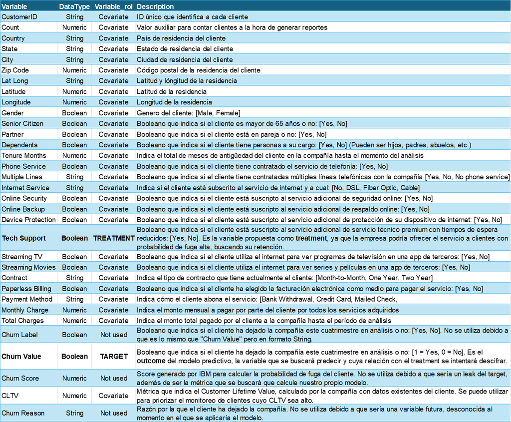

En este notebook se realizará un análisis descriptivo de todas las variables que componen el dataset, tanto desde el punto de vista estadístico y programático como desde el punto de vista gráfico.

## Librerías y funciones

Sección en la que se importan las librerías públicas y también se importan funciones personalizadas desde un script propio.

```python
import pandas as pd
import numpy as np
import matplotlib.pyplot as plt
import seaborn as sns
import sys
import importlib
import warnings

pd.set_option('display.max_columns', 500)
pd.set_option('display.max_rows', 500)

SEED=10
```

```python
sys.path.append('../src/')
import functions_rfc_IBM as fr
importlib.reload(fr)
sys.path.remove('../src/')
```

## Carga del dataset y breve análisis estadístico descriptivo

- Carga del set de datos desde su formato original (Excel)
- Visualización simple de los tipos de variables y algunos estadísticos descriptivos básicos

```python
df_telco = pd.read_excel('../data/ibm_telco_churn/Telco_customer_churn.xlsx')
display(df_telco.head(), df_telco.shape)
```

|  | CustomerID | Count | Country | State | City | Zip Code | Lat Long | Latitude | Longitude | Gender | Senior Citizen | Partner | Dependents | Tenure Months | Phone Service | Multiple Lines | Internet Service | Online Security | Online Backup | Device Protection | Tech Support | Streaming TV | Streaming Movies | Contract | Paperless Billing | Payment Method | Monthly Charges | Total Charges | Churn Label | … |
| --- | --- | --- | --- | --- | --- | --- | --- | --- | --- | --- | --- | --- | --- | --- | --- | --- | --- | --- | --- | --- | --- | --- | --- | --- | --- | --- | --- | --- | --- | --- |
| 0 | 3668-QPYBK | 1 | United States | California | Los Angeles | 90003 | 33.964131, -118.272783 | 33.964131 | -118.272783 | Male | No | No | No | 2 | Yes | No | DSL | Yes | Yes | No | No | No | No | Month-to-month | Yes | Mailed check | 53.85 | 108.15 | Yes | … |
| 1 | 9237-HQITU | 1 | United States | California | Los Angeles | 90005 | 34.059281, -118.30742 | 34.059281 | -118.307420 | Female | No | No | Yes | 2 | Yes | No | Fiber optic | No | No | No | No | No | No | Month-to-month | Yes | Electronic check | 70.70 | 151.65 | Yes | … |
| 2 | 9305-CDSKC | 1 | United States | California | Los Angeles | 90006 | 34.048013, -118.293953 | 34.048013 | -118.293953 | Female | No | No | Yes | 8 | Yes | Yes | Fiber optic | No | No | Yes | No | Yes | Yes | Month-to-month | Yes | Electronic check | 99.65 | 820.5 | Yes | … |
| 3 | 7892-POOKP | 1 | United States | California | Los Angeles | 90010 | 34.062125, -118.315709 | 34.062125 | -118.315709 | Female | No | Yes | Yes | 28 | Yes | Yes | Fiber optic | No | No | Yes | Yes | Yes | Yes | Month-to-month | Yes | Electronic check | 104.80 | 3046.05 | Yes | … |
| 4 | 0280-XJGEX | 1 | United States | California | Los Angeles | 90015 | 34.039224, -118.266293 | 34.039224 | -118.266293 | Male | No | No | Yes | 49 | Yes | Yes | Fiber optic | No | Yes | Yes | No | Yes | Yes | Month-to-month | Yes | Bank transfer (automatic) | 103.70 | 5036.3 | Yes | … |

```
(7043, 33)
```

Se cuenta con 7043 instancias y 33 variables.

```python
df_telco.describe().T.style.format("{:.2f}")
```

|  | count | mean | std | min | 25% | 50% | 75% | max |
| --- | --- | --- | --- | --- | --- | --- | --- | --- |
| Count | 7043.00 | 1.00 | 0.00 | 1.00 | 1.00 | 1.00 | 1.00 | 1.00 |
| Zip Code | 7043.00 | 93521.96 | 1865.79 | 90001.00 | 92102.00 | 93552.00 | 95351.00 | 96161.00 |
| Latitude | 7043.00 | 36.28 | 2.46 | 32.56 | 34.03 | 36.39 | 38.22 | 41.96 |
| Longitude | 7043.00 | -119.80 | 2.16 | -124.30 | -121.82 | -119.73 | -118.04 | -114.19 |
| Tenure Months | 7043.00 | 32.37 | 24.56 | 0.00 | 9.00 | 29.00 | 55.00 | 72.00 |
| Monthly Charges | 7043.00 | 64.76 | 30.09 | 18.25 | 35.50 | 70.35 | 89.85 | 118.75 |
| Churn Value | 7043.00 | 0.27 | 0.44 | 0.00 | 0.00 | 0.00 | 1.00 | 1.00 |
| Churn Score | 7043.00 | 58.70 | 21.53 | 5.00 | 40.00 | 61.00 | 75.00 | 100.00 |
| CLTV | 7043.00 | 4400.30 | 1183.06 | 2003.00 | 3469.00 | 4527.00 | 5380.50 | 6500.00 |

Son relativamente pocas las variables numéricas, además de que algunas parece que serán poco útiles (Count por ejemplo es siempre 1)

```python
df_telco.info()
```

```
<class 'pandas.core.frame.DataFrame'>
RangeIndex: 7043 entries, 0 to 7042
Data columns (total 33 columns):
 #   Column             Non-Null Count  Dtype
---  ------             --------------  -----
 0   CustomerID         7043 non-null   object
 1   Count              7043 non-null   int64
 2   Country            7043 non-null   object
 3   State              7043 non-null   object
 4   City               7043 non-null   object
 5   Zip Code           7043 non-null   int64
 6   Lat Long           7043 non-null   object
 7   Latitude           7043 non-null   float64
 8   Longitude          7043 non-null   float64
 9   Gender             7043 non-null   object
```

[output cut: 25 more lines]

## Variable target y treatment

Se visualiza la distribución de la variable objetivo ('Churn Value') y de la que, a priori, será la variable tratamiento ('Tech Support')

```python
df_telco['Churn Value'].value_counts(normalize=True)
```

```
Churn Value
0    0.73463
1    0.26537
Name: proportion, dtype: float64
```

Hay un cierto desbalanceo en la variable target, aunque dentro de los parámetros normales, no es tan grave como lo suele ser en otros casos

```python
df_telco['Tech Support'].value_counts(normalize=True)
```

```
Tech Support
No                     0.493114
Yes                    0.290217
No internet service    0.216669
Name: proportion, dtype: float64
```

Cabe recalcar que sería injusto y sesgado comparar personas sin posibilidad de tener el tratamiento, por lo que, a fines del análisis de este trabajo se procederá a filtrar el dataset, manteniendo solo a quienes pueden adquirir o no el Tech Support (quienes tienen contratado el servicio de internet).

```python
df_telco = df_telco[df_telco['Tech Support'].isin(['Yes', 'No'])]
display(df_telco.head(), df_telco.shape)
```

|  | CustomerID | Count | Country | State | City | Zip Code | Lat Long | Latitude | Longitude | Gender | Senior Citizen | Partner | Dependents | Tenure Months | Phone Service | Multiple Lines | Internet Service | Online Security | Online Backup | Device Protection | Tech Support | Streaming TV | Streaming Movies | Contract | Paperless Billing | Payment Method | Monthly Charges | Total Charges | Churn Label | … |
| --- | --- | --- | --- | --- | --- | --- | --- | --- | --- | --- | --- | --- | --- | --- | --- | --- | --- | --- | --- | --- | --- | --- | --- | --- | --- | --- | --- | --- | --- | --- |
| 0 | 3668-QPYBK | 1 | United States | California | Los Angeles | 90003 | 33.964131, -118.272783 | 33.964131 | -118.272783 | Male | No | No | No | 2 | Yes | No | DSL | Yes | Yes | No | No | No | No | Month-to-month | Yes | Mailed check | 53.85 | 108.15 | Yes | … |
| 1 | 9237-HQITU | 1 | United States | California | Los Angeles | 90005 | 34.059281, -118.30742 | 34.059281 | -118.307420 | Female | No | No | Yes | 2 | Yes | No | Fiber optic | No | No | No | No | No | No | Month-to-month | Yes | Electronic check | 70.70 | 151.65 | Yes | … |
| 2 | 9305-CDSKC | 1 | United States | California | Los Angeles | 90006 | 34.048013, -118.293953 | 34.048013 | -118.293953 | Female | No | No | Yes | 8 | Yes | Yes | Fiber optic | No | No | Yes | No | Yes | Yes | Month-to-month | Yes | Electronic check | 99.65 | 820.5 | Yes | … |
| 3 | 7892-POOKP | 1 | United States | California | Los Angeles | 90010 | 34.062125, -118.315709 | 34.062125 | -118.315709 | Female | No | Yes | Yes | 28 | Yes | Yes | Fiber optic | No | No | Yes | Yes | Yes | Yes | Month-to-month | Yes | Electronic check | 104.80 | 3046.05 | Yes | … |
| 4 | 0280-XJGEX | 1 | United States | California | Los Angeles | 90015 | 34.039224, -118.266293 | 34.039224 | -118.266293 | Male | No | No | Yes | 49 | Yes | Yes | Fiber optic | No | Yes | Yes | No | Yes | Yes | Month-to-month | Yes | Bank transfer (automatic) | 103.70 | 5036.3 | Yes | … |

```
(5517, 33)
```

```python
df_telco['Churn Value'].value_counts(normalize=True), df_telco['Tech Support'].value_counts(normalize=True)
```

```
(Churn Value
 0    0.681711
 1    0.318289
 Name: proportion, dtype: float64,
 Tech Support
 No     0.629509
 Yes    0.370491
 Name: proportion, dtype: float64)
```

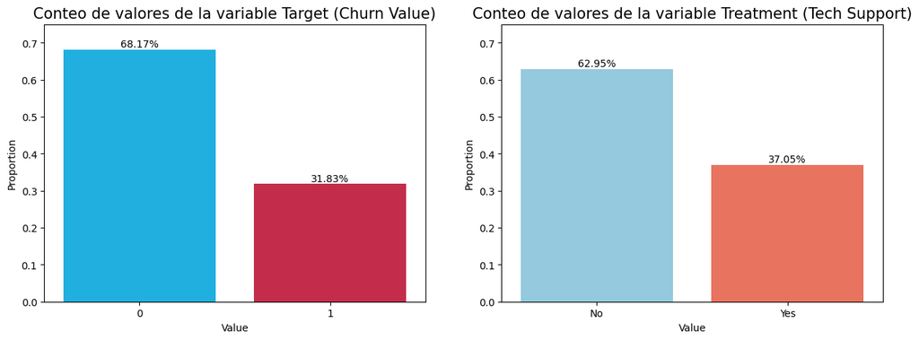

```python
target_perc = df_telco['Churn Value'].value_counts(normalize=True).reset_index()
treatment_perc = df_telco['Tech Support'].value_counts(normalize=True).reset_index()

fig, (ax1, ax2) = plt.subplots(1,2, figsize=(15,5))
sns.barplot(data=target_perc, x='Churn Value', y='proportion', ax=ax1, hue='proportion',legend=False, palette=['crimson','deepskyblue'])
ax1.set_title('Conteo de valores de la variable Target (Churn Value)', fontdict={'fontsize':15}) #,'fontname':'Montserrat','weight':'bold'
#ax.yaxis.set_major_formatter('{x:,.0f}')
for i in ax1.containers:
    ax1.bar_label(i,fmt='{:.2%}')
ax1.set_ylabel('Proportion')
ax1.set_xlabel('Value')
ax1.set_ylim(0.0,0.75)

sns.barplot(data=treatment_perc, x='Tech Support', y='proportion', ax=ax2, hue='proportion',legend=False, palette=['tomato','skyblue'])
ax2.set_title('Conteo de valores de la variable Treatment (Tech Support)', fontdict={'fontsize':15}) #,'fontname':'Montserrat','weight':'bold'
#ax.yaxis.set_major_formatter('{x:,.0f}')
for i in ax2.containers:
    ax2.bar_label(i,fmt='{:.2%}')
ax2.set_ylabel('Proportion')
ax2.set_xlabel('Value')
ax2.set_ylim(0.0,0.75)
plt.show()
```

Luego del filtrado el desbalanceo se mantiene vigente pero se ha visto disminuído levemente.

```python
pd.concat([df_telco[df_telco['Churn Value'] == 1]['Tech Support'].value_counts(normalize=True)
          ,df_telco[df_telco['Churn Value'] == 0]['Tech Support'].value_counts(normalize=True)]
          ,axis=1
          ,keys=['Churn', 'No Churn'])\
    .fillna(0)\
    .style.format("{:.2%}").background_gradient(cmap='Blues', low=0, high=1, subset=['Churn'])
```

| Tech Support | Churn | No Churn |
| --- | --- | --- |
| No | 82.35% | 53.90% |
| Yes | 17.65% | 46.10% |

Se puede observar cierta tendencia en la que, en caso de contar con un soporte técnico superior, la propención a la fuga parece ser menor a priori

```python
crosstab = pd.crosstab(df_telco['Tech Support'], df_telco['Churn Value'])
crosstab
```

| Churn Value Tech Support | 0 | 1 |
| --- | --- | --- |
| No | 2027 | 1446 |
| Yes | 1734 | 310 |

```python
fr.cramers_v(crosstab)
```

```
0.27371275672450684
```

Al tratarse de variables categóricas no es posible aplicar el coeficiente de correlación, pero si es posible utilizar otro estadístico como lo es el Cramers V, que permite obtener un coeficiente parecido que mide asociación entre variables de tipo categóricas. En este caso no es extremo pero parece ser relativamente alto.

Este sería el símil a la correlación entre dichas variables, aunque con la contra de que está expresado en valor absoluto, por lo que no necesariamente se indica que mientras más tratamiento más fuga habrá, se intuye incluso que debería ser al contrario, en base a lo visto anteriormente.

## Tipos de las variables

Se utiliza una función de autor para determinar el tipo de las variables de manera automática y luego realizar los ajustes pertinentes a dicha clasificación.

```python
fr.tipos_vars(df_telco)
```

```
(categoric)\(Type: object) - CustomerID : Unique values = 5517. Sample: ['3668-QPYBK' '9237-HQITU' '9305-CDSKC' '7892-POOKP' '0280-XJGEX'] ... ['7750-EYXWZ' '6840-RESVB' '2234-XADUH' '4801-JZAZL' '3186-AJIEK']
(boolean) - Count :  [1]
(boolean) - Country :  ['United States']
(boolean) - State :  ['California']
(categoric)\(Type: object) - City : Unique values = 1127. Sample: ['Los Angeles' 'Beverly Hills' 'Huntington Park' 'Lynwood'
 'Marina Del Rey'] ... ['Laton' 'Belvedere Tiburon' 'Orick' 'Phillipsville' 'Salton City']
(numeric) - Zip Code : Range = [90001.00 to 96161.00], Mean = 93511.25
(categoric)\(Type: object) - Lat Long : Unique values = 1649. Sample: ['33.964131, -118.272783' '34.059281, -118.30742' '34.048013, -118.293953'
 '34.062125, -118.315709' '34.039224, -118.266293'] ... ['37.885629, -122.46858' '41.336354, -124.044354' '40.184094, -123.745487'
 '38.512569, -121.495184' '33.28156, -115.955541']
(numeric) - Latitude : Range = [32.56 to 41.96], Mean = 36.25
(numeric) - Longitude : Range = [-124.30 to -114.19], Mean = -119.76
(boolean) - Gender :  ['Male' 'Female']
(boolean) - Senior Citizen :  ['No' 'Yes']
(boolean) - Partner :  ['No' 'Yes']
(boolean) - Dependents :  ['No' 'Yes']
(numeric) - Tenure Months : Range = [0.00 to 72.00], Mean = 32.88
(boolean) - Phone Service :  ['Yes' 'No']
(categoric)(Type: object) - Multiple Lines : ['No', 'No phone service', 'Yes']
(boolean) - Internet Service :  ['DSL' 'Fiber optic']
(boolean) - Online Security :  ['Yes' 'No']
(boolean) - Online Backup :  ['Yes' 'No']
(boolean) - Device Protection :  ['No' 'Yes']
(boolean) - Tech Support :  ['No' 'Yes']
(boolean) - Streaming TV :  ['No' 'Yes']
(boolean) - Streaming Movies :  ['No' 'Yes']
(categoric)(Type: object) - Contract : ['Month-to-month', 'One year', 'Two year']
(boolean) - Paperless Billing :  ['Yes' 'No']
(categoric)(Type: object) - Payment Method : ['Bank transfer (automatic)', 'Credit card (automatic)', 'Electronic check', 'Mailed check']
(numeric) - Monthly Charges : Range = [23.45 to 118.75], Mean = 76.84
(categoric)\(Type: object) - Total Charges : Unique values = 5259. Sample: [108.15 151.65 820.5 3046.05 5036.3] ... [743.3 1990.5 7362.9 346.45 6844.5]
(boolean) - Churn Label :  ['Yes' 'No']
(boolean) - Churn Value :  [1 0]
(numeric) - Churn Score : Range = [5.00 to 100.00], Mean = 60.35
(numeric) - CLTV : Range = [2003.00 to 6500.00], Mean = 4407.46
(categoric)(Type: object) - Churn Reason : ['Attitude of service provider', 'Attitude of support person', 'Competitor had better devices', 'Competitor made better offer', 'Competitor offered higher download speeds', 'Competitor offered more data', 'Deceased', "Don't know", 'Extra data charges', 'Lac…
```

```
(['Count',
  'Country',
  'State',
  'Gender',
  'Senior Citizen',
  'Partner',
  'Dependents',
  'Phone Service',
  'Internet Service',
  'Online Security',
  'Online Backup',
  'Device Protection',
  'Tech Support',
  'Streaming TV',
  'Streaming Movies',
  'Paperless Billing',
  'Churn Label',
  'Churn Value'],
 ['CustomerID',
  'City',
  'Lat Long',
  'Multiple Lines',
  'Contract',
  'Payment Method',
  'Total Charges',
  'Churn Reason'],
 ['Zip Code',
  'Latitude',
  'Longitude',
  'Tenure Months',
  'Monthly Charges',
  'Churn Score',
  'CLTV'])
```

Se encuentra que la variable 'Total Charges' es tipo String cuando debería ser de tipo numérica, por lo que se procede a modificar su tipo:

```python
df_telco['Total Charges'] = df_telco['Total Charges'].replace(' ', np.nan).astype(float)
```

Una vez ajustado, se procede a verificar y guardar en listas los nombres de las variables según su tipo asignado

```python
bools, cats, nums = fr.tipos_vars(df_telco)
```

[output not shown]

```python
var_types_count = pd.DataFrame([['Boolean',len(bools)]
                                ,['Categoric',len(cats)]
                                ,['Numeric',len(nums)]]
                                ,columns=['Var_type','Count'])
var_types_count
```

|  | Var_type | Count |
| --- | --- | --- |
| 0 | Boolean | 18 |
| 1 | Categoric | 7 |
| 2 | Numeric | 8 |

## Primera selección de variables

Existen algunas variables que si o si deberán ser eliminadas del análisis ya sea porque no es correcto considerarlas (como el ID), porque sesgan o filtran información del target (variables derivadas del target como Churn Score), porque son derivados de otras variables y no suman información (latitud y longitud, existiendo ya la ciudad) porque tienen un único valor (Count, Country, State), o por ser una variable futura, no disponible a la hora del análisis (Churn Reason).

Esto conformará la primer selección de variables y será tenido en cuenta luego al generar la función feature_selection.

```python
del_features = ['CustomerID'
                ,'Count'
                ,'Country'
                ,'State'
                ,'Zip Code'
                ,'Lat Long'
                ,'Latitude'
                ,'Longitude'
                ,'Churn Score'
                ,'Churn Label'
                ,'Churn Reason']
```

```python
df_telco = df_telco.drop(columns=del_features, axis=1)
```

```python
bools, cats, nums = fr.tipos_vars(df_telco)
```

[output not shown]

```python
var_types_count = pd.DataFrame([['Boolean',len(bools)]
                                ,['Categoric',len(cats)]
                                ,['Numeric',len(nums)]]
                                ,columns=['Var_type','Count'])
var_types_count
```

|  | Var_type | Count |
| --- | --- | --- |
| 0 | Boolean | 14 |
| 1 | Categoric | 4 |
| 2 | Numeric | 4 |

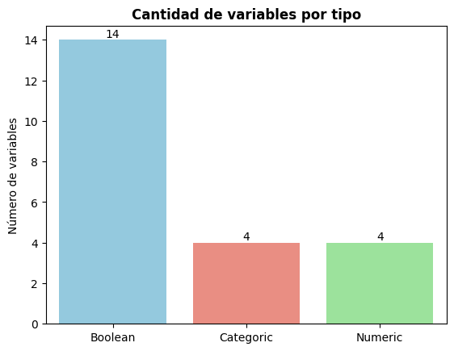

```python
fig, ax = plt.subplots()
sns.barplot(data=var_types_count,x='Var_type',y='Count', palette=['skyblue','salmon','lightgreen'], ax=ax, hue='Var_type')
ax.set_title('Cantidad de variables por tipo', weight='bold')
ax.set_ylabel('Número de variables')
ax.set_xlabel('')
for i in ax.containers:
    ax.bar_label(i,fmt='{:,.0f}')
plt.show()
```

El conteo de variables luego de la primer selección muestra la predominancia de los booleanos, existiendo solo 4 variables categóricas y 4 numéricas

```python
fr.nulls_detection(df_telco)
```

|  | Missing Values | Percentage | Type |
| --- | --- | --- | --- |
| Total Charges | 5 | 0.09% | float64 |

Se detectan solo 5 valors missing, los cuales serán reemplazados por la mediana al tratarse de una variable numérica continua

```python
df_telco['Total Charges'] = df_telco['Total Charges'].fillna(df_telco['Total Charges'].median())
```

```python
fr.nulls_detection(df_telco)
```

|  | Missing Values | Percentage | Type |
| --- | --- | --- | --- |

## Análisis gráfico exploratorio

A continuación se procede a realizar un análisis gráfico de las variables y su relación con el target.

Debido a que la variable 'City' se trata de una variable categórica con una gran cantidad de valores únicos, su visualización no aporta al análsis, por lo que se le realiza una breve visualización en tablas a continuación.

Luego, se procede al análsis general de las variables en cuanto a su distribución y a su relación con el target.

```python
pd.concat([df_telco[df_telco['Churn Value'] == 1]['City'].value_counts(normalize=True)
          ,df_telco[df_telco['Churn Value'] == 0]['City'].value_counts(normalize=True)]
          ,axis=1
          ,keys=['Churn', 'No Churn'])\
    .fillna(0)\
    .assign(Diff = lambda x: x['Churn'] - x['No Churn'])\
    .sort_values(by='Diff', ascending=False)\
    .head(20)\
    .style.format("{:.2%}").background_gradient(cmap='Reds', low=0, high=1)
```

| City | Churn | No Churn | Diff |
| --- | --- | --- | --- |
| Los Angeles | 4.90% | 3.99% | 0.91% |
| San Francisco | 1.71% | 1.17% | 0.54% |
| Santa Rosa | 0.57% | 0.16% | 0.41% |
| La Puente | 0.40% | 0.05% | 0.35% |
| Modesto | 0.63% | 0.32% | 0.31% |
| San Diego | 2.56% | 2.26% | 0.30% |
| Apple Valley | 0.34% | 0.08% | 0.26% |
| El Monte | 0.34% | 0.08% | 0.26% |
| Santa Barbara | 0.57% | 0.32% | 0.25% |
| Temecula | 0.34% | 0.11% | 0.24% |
| Novato | 0.34% | 0.11% | 0.24% |
| Lompoc | 0.28% | 0.05% | 0.23% |
| Eldridge | 0.23% | 0.00% | 0.23% |
| Wrightwood | 0.23% | 0.00% | 0.23% |
| Johannesburg | 0.23% | 0.00% | 0.23% |
| South Lake Tahoe | 0.23% | 0.00% | 0.23% |
| Riverbank | 0.23% | 0.00% | 0.23% |
| Truckee | 0.23% | 0.00% | 0.23% |
| Tipton | 0.23% | 0.00% | 0.23% |
| Fort Jones | 0.23% | 0.00% | 0.23% |

Los datos parecen estar extremadamente distribuídos

```python
pd.concat([
(df_telco
 .groupby('City')['Churn Value']
 .value_counts(normalize=True)
 .unstack()
 .assign(Diff = lambda x: x[1] - x[0])
 .fillna(0)
 .rename(columns={0:'No Churn %', 1:'Churn %'})
)
,(df_telco
    .groupby('City')['Churn Value']
    .value_counts()
    .unstack()
    .assign(Total = lambda x: x[0] + x[1])
    .fillna(0)
    .rename(columns={0:'No Churn', 1:'Churn'})
    )
    ],axis=1
).reset_index()\
 .query('Total > 8')\
 .sort_values(by='Diff', ascending=False)\
 .iloc[np.r_[0:5, -5:0]]\
 .style.format({'Churn %':"{:.2%}"
                ,'No Churn %':"{:.2%}"
                ,'Diff':"{:.2%}"
                ,'Churn':"{:.0f}"
                ,'No Churn':"{:.0f}"
                ,'Total':"{:.0f}"})\
 .background_gradient(cmap='coolwarm', subset=['Diff'])
```

| Churn Value | City | No Churn % | Churn % | Diff | No Churn | Churn | Total |
| --- | --- | --- | --- | --- | --- | --- | --- |
| 498 | La Puente | 22.22% | 77.78% | 55.56% | 2 | 7 | 9 |
| 292 | El Monte | 33.33% | 66.67% | 33.33% | 3 | 6 | 9 |
| 32 | Apple Valley | 33.33% | 66.67% | 33.33% | 3 | 6 | 9 |
| 907 | Santa Rosa | 37.50% | 62.50% | 25.00% | 6 | 10 | 16 |
| 1001 | Temecula | 40.00% | 60.00% | 20.00% | 4 | 6 | 10 |
| 641 | Monterey Park | 88.89% | 11.11% | -77.78% | 8 | 1 | 9 |
| 213 | Compton | 90.00% | 10.00% | -80.00% | 9 | 1 | 10 |
| 77 | Beverly Hills | 90.91% | 9.09% | -81.82% | 10 | 1 | 11 |
| 362 | Gardena | 92.31% | 7.69% | -84.62% | 12 | 1 | 13 |
| 56 | Bakersfield | 92.86% | 7.14% | -85.71% | 26 | 2 | 28 |

Las ciudades que destacan negativa o positivamente no tienen una gran cantidad de observaciones totales, por lo que a priori no pareciese ser una variable que pueda aportar mucho, al menos en su estado actual.

Al tratarse de una variable tan atomizada, esto deberá ser tenido en cuenta a la hora de su encoding. Sobre esto se profundizará en el siguiente notebook.

Solo a fines de visualización se modificarán los valores de la variable Payment Method, para que se ubiquen correctamente en el gráfico los títulos

```python
df_telco['Payment Method'] = (df_telco['Payment Method']
                                .replace('Mailed check', 'Mail')
                                .replace('Electronic check', 'E.C.')
                                .replace('Bank transfer (automatic)', 'B.T. - Auto')
                                .replace('Credit card (automatic)', 'C.C. - Auto')
                                )

df_telco['Payment Method'].unique()
```

```
array(['Mail', 'E.C.', 'B.T. - Auto', 'C.C. - Auto'], dtype=object)
```

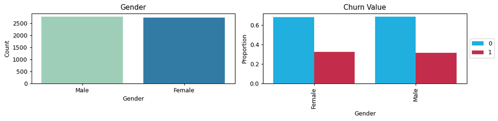

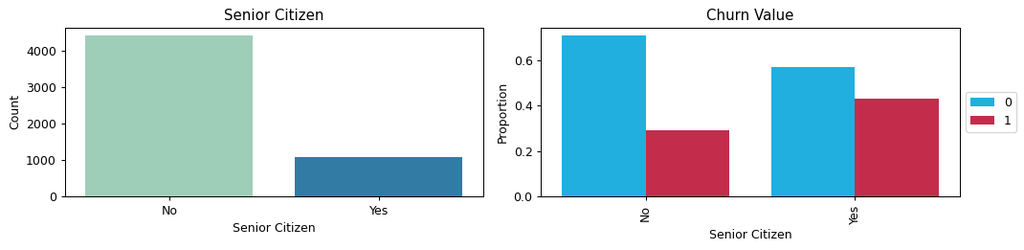

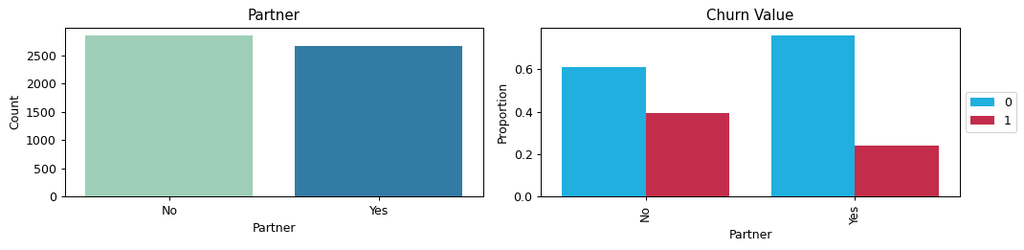

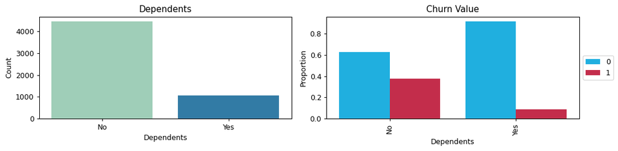

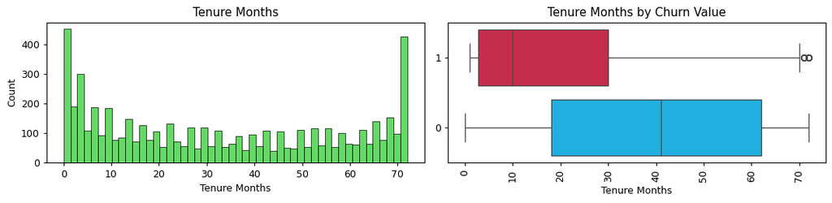

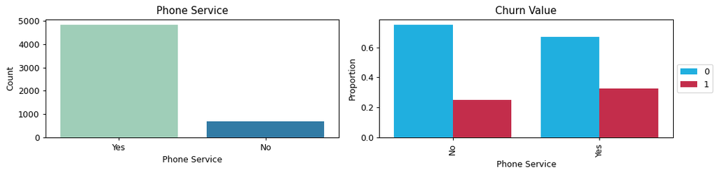

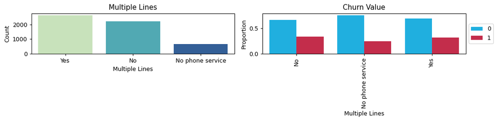

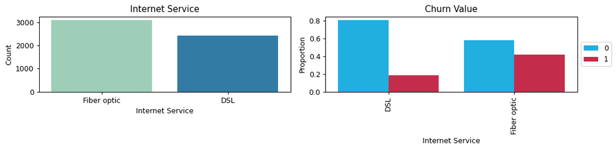

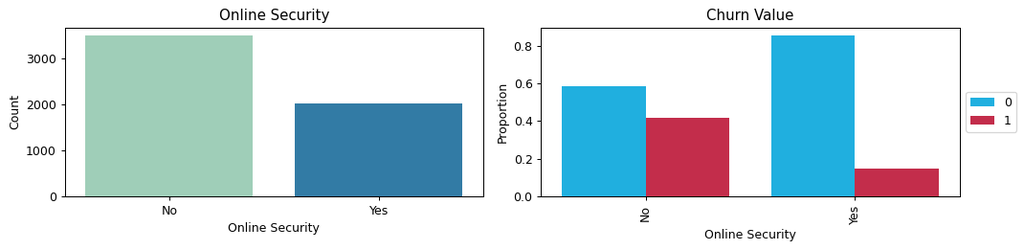

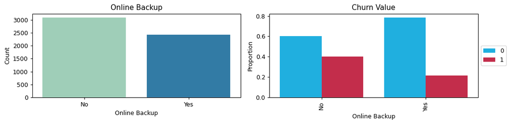

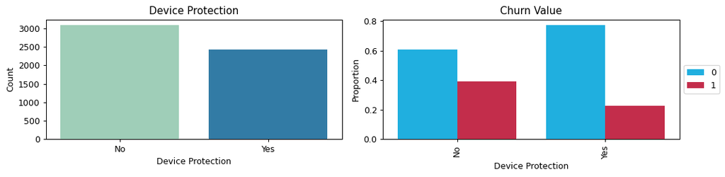

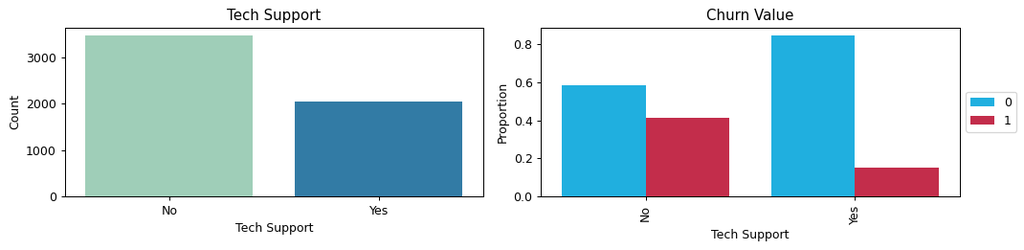

[8 more figures not shown]

```
CPU times: total: 2.58 s
Wall time: 7.35 s
```

```python
%%time
warnings.filterwarnings('ignore')
for i in list(df_telco.columns):
    if i=='City':
        pass
    elif i in nums:
        fr.double_plot(df_telco, col_name=i, is_cont=True, target='Churn Value', y_scale='linear', palette={'0':'deepskyblue','1':'crimson'})
    elif  ((i in bools) | (i in cats)) & (i!='Churn Value'):
        fr.double_plot(df_telco, col_name=i, is_cont=False, target='Churn Value', y_scale='linear', palette={'0':'deepskyblue','1':'crimson'})
```

### Puntos a destacar del análisis gráfico:

1. Se vuelve a ver como la variable treatment parece discriminar en cierta medida a los clientes que se han fugado y los que no
2. Más aún parecen discriminar las variables 'Ternure' y 'Contract'. Esto parece lógico debido a que mientras mayor es la cantidad de meses que lleva un cliente subscrito y mientras mayor sea la duración del contrato en vigencia, se podría intuír que su propención a la fuga podría ser menor.
3. El cargo mensual no parece ser un factor tan determinante como uno podría pensar a priori, estando las medianas de los fugados y los no fugados en rangos muy similares
4. Las variables 'Dependents' y 'Payment Method' también parecen ser bastante discriminantes del target. Mientras que un valor positivo en la primera de ellas parece disminuír la probabilidad de fuga, los métodos de pago no automáticos parecen aumentarla.
5. Variables como el género o los servicios de streaming que tiene el cliente parecen ser bastante insignificantes para el análisis.

## Correlaciones entre variables

A continuación se procede a medir los coeficientes de asociación entre las variables, tanto numéricas como categóricas

##### Variables numéricas: Coeficiente de correlación de pearsons + Matriz de correlaciones

```python
corr = pd.concat([df_telco[nums],df_telco['Churn Value']], axis=1).corr()
```

```python
fr.plot_corr?
```

```
Signature:
fr.plot_corr(
    corr,
    title='Matriz de correlaciones',
    figsize=(14, 8),
    target_text=False,
    annot_floor=0.4,
    annot_all=False,
    cmap='icefire',
    vmin=-1,
    vmax=1,
    fmt='.1f',
)
Docstring:
----------------------------------------------------------------------------------------------------------
Función plot_corr:
----------------------------------------------------------------------------------------------------------
- Funcionamiento:
    La función recibe una matriz de correlaciones y genera un gráfico tipo heatmap en base a ella.
    Se pueden determinar el título, tamaño del gráfico, y que cuadrantes tengan o no el valor de la
    correlación.
- Inputs:
    - corr: Dataframe de la matriz de correlaciones
    - title: Título elegido. Por defecto será 'Matriz de correlaciones'
    - figsize: Tamaño del gráfico
    - target_text: Se debe activar si se desean mostrar todos los valores en los cuadrantes de la última
    fila de la matriz, en mi caso usada para colocar a la variable target.
    - annot_floor: Valor desde el cual se pretenden mostrar los valores de las correlaciones en los
    cuadrantes de la matriz.
    - annot_all: Si es verdadero, se muestran los valores en todos los cuadrantes de la matriz.
File:      c:\users\rodri\onedrive\documentos\studies\master_cunef_data_science\tfm\src\functions_rfc_ibm.py
Type:      function
```

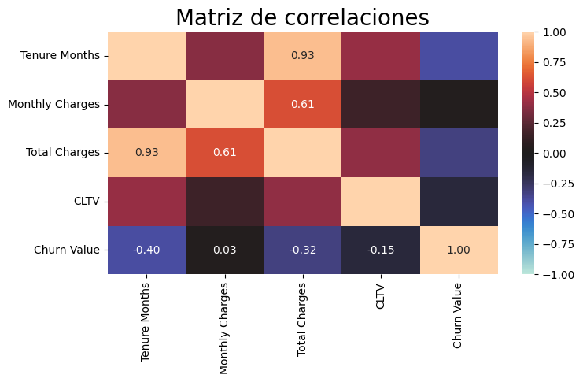

```python
fr.plot_corr(corr=corr, figsize=(8,4), annot_floor=0.6, fmt='.2f', target_text=True)
```

Ternure y Total Charges están muy relacionadas, ya que como suena lógico, una mayor estancia indica una mayor cantidad de pagos totales. Además, los cargos totales se relacionan también con el cargo mensual, ya que mientras más se pague por mes más rápido aumentará dicho valor. Por ende, puede ser un confounder cuyo valor no aporte mucho teniendo ya las otras dos variables, por lo que posiblemente sea conveniente eliminar la variable 'Total Charges'.

```python
del_features.append('Total Charges')
nums.remove('Total Charges')
```

```python
df_telco = df_telco.drop('Total Charges', axis=1)
```

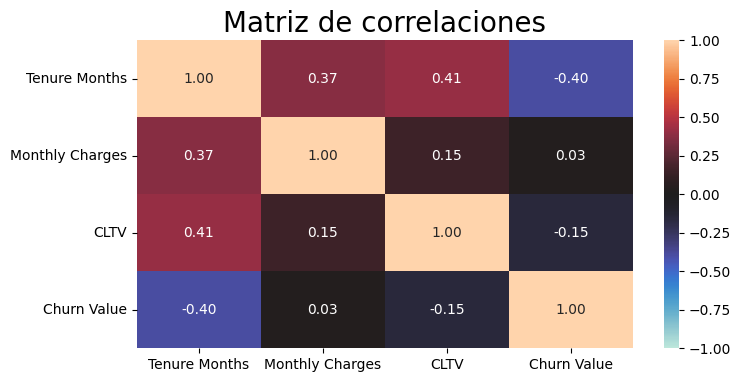

```python
corr = pd.concat([df_telco[nums],df_telco['Churn Value']], axis=1).corr()
fr.plot_corr(corr=corr, figsize=(8,4), annot_all=True, fmt='.2f', target_text=True)
```

##### Variables categóricas: Cramers V + Cramers Asociation Matrix

```python
fr.corr_cat?
```

```
Signature: fr.corr_cat(df, target=None, target_transform=False, cat_cols=None)
Docstring:
----------------------------------------------------------------------------------------------------------
Función corr_cat:
----------------------------------------------------------------------------------------------------------
- Funcionamiento:
    La función recibe como un dataframe, detecta las variables categóricas y calcula una especie de
    matriz de correlaciones mediante el uso del estadístico Cramers V. En la función se incluye la
    posibilidad de que se transforme a la variable target a string si no lo fuese y que se incluya en la
    lista de variables a analizar. Esto último  puede servir sobre todo para casos en los que la variable
    target es un booleano o está codificada.
- Inputs:
    -- df: DataFrame de Pandas a analizar
    -- target: String con nombre de la variable objetivo
    -- target_transform: Transforma la variable objetivo a string para el procesamiento y luego la vuelve
    a su tipo original.
- Return:
    -- corr_cat: matriz con los Cramers V cruzados.
File:      c:\users\rodri\onedrive\documentos\studies\master_cunef_data_science\tfm\src\functions_rfc.py
Type:      function
```

```python
corr_cat = fr.corr_cat(df=df_telco, target='Churn Value', cat_cols=cats+bools)
```

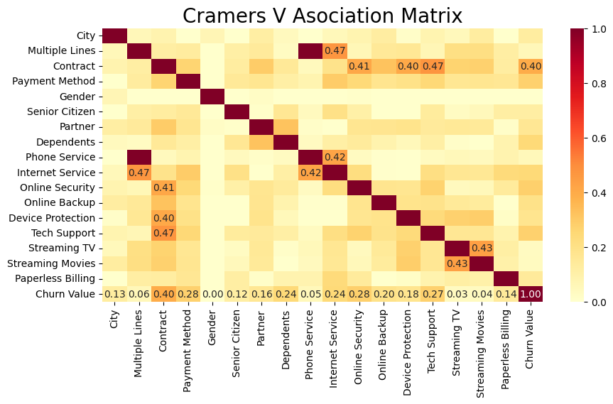

```python
fr.plot_corr(corr_cat, title='Cramers V Asociation Matrix', figsize=(10,5), target_text=True, cmap='YlOrRd', vmin=0, fmt='.2f')
```

Gracias a este interesante test estadístico podemos observar asociaciones entre la mayor cantidad de variables que tenemos. En este caso resaltan algunas relaciones con el target como sobre todo la de la variable 'Contract', seguida por 'Payment Method' y el treatment ('Tech Support').

Destaca además una correlación casi perfecta entre 'Phone Service' y 'Multiple Lines', por lo que se procede a evaluar la eliminación de una de ellas:

```python
fr.cramers_v(pd.crosstab(df_telco['Multiple Lines'], df_telco['Phone Service']))
```

```
0.9999093340584747
```

```python
pd.crosstab(df_telco['Multiple Lines'], df_telco['Phone Service'], normalize='index')
```

| Phone Service Multiple Lines | No | Yes |
| --- | --- | --- |
| No | 0.0 | 1.0 |
| No phone service | 1.0 | 0.0 |
| Yes | 0.0 | 1.0 |

Multiple lines parece ser una variable que no agrega valor y tiene una correlación perfecta con Phone Service, por lo que se procede a eliminarla.

```python
del_features.append('Multiple Lines')
cats.remove('Multiple Lines')
```

```python
df_telco = df_telco.drop('Multiple Lines', axis=1)
```

```python
pd.crosstab(df_telco['Contract'], df_telco['Tech Support'], normalize='index')
```

| Tech Support Contract | No | Yes |
| --- | --- | --- |
| Month-to-month | 0.799761 | 0.200239 |
| One year | 0.502254 | 0.497746 |
| Two year | 0.223273 | 0.776727 |

```python
(pd.DataFrame(pd.concat([corr
                .loc['Churn Value']
               ,corr_cat
                .loc['Churn Value']
               ]
               ,axis=0)
               .sort_values(ascending=False)
            )
            .rename(columns={'Churn Value':'Correlation'})
            .reset_index(names='Variable')
            .query('Variable != "Churn Value"')
            .style.format({'Correlation':"{:.2f}"})
            .background_gradient(cmap='coolwarm', vmin=-1, vmax=1)
)
```

|  | Variable | Correlation |
| --- | --- | --- |
| 2 | Contract | 0.40 |
| 3 | Online Security | 0.28 |
| 4 | Payment Method | 0.28 |
| 5 | Tech Support | 0.27 |
| 6 | Dependents | 0.24 |
| 7 | Internet Service | 0.24 |
| 8 | Online Backup | 0.20 |
| 9 | Device Protection | 0.18 |
| 10 | Partner | 0.16 |
| 11 | Paperless Billing | 0.14 |
| 12 | City | 0.13 |
| 13 | Senior Citizen | 0.12 |
| 14 | Multiple Lines | 0.06 |
| 15 | Phone Service | 0.05 |
| 16 | Streaming Movies | 0.04 |
| 17 | Streaming TV | 0.03 |
| 18 | Monthly Charges | 0.03 |
| 19 | Gender | 0.00 |
| 20 | CLTV | -0.15 |
| 21 | Tenure Months | -0.40 |

Finalmente, se muestra un resumen de las principales variables relacionadas al target, destacando 'Contract' y 'Ternure Months'

```python
del_features
```

```
['CustomerID',
 'Count',
 'Country',
 'State',
 'Zip Code',
 'Lat Long',
 'Latitude',
 'Longitude',
 'Churn Score',
 'Churn Label',
 'Churn Reason',
 'Total Charges',
 'Multiple Lines']
```

Se vuelven a mostrar las variables que serán eliminadas en el próximo notebook: Preprocesamiento.

# Transformando dataset a Parquet

SIN modificaciones, ya que todas se aglutinarán en el notebook de Preprocesamiento.

###### *Solo es necesario determinar los nulls de una columna, ya que de lo contrario no funciona el to_parquet de pandas*

```python
df_telco_raw = pd.read_excel('../data/ibm_telco_churn/Telco_customer_churn.xlsx')
```

```python
df_telco_raw['Total Charges'] = df_telco_raw['Total Charges'].replace(' ', np.nan).astype(float)
```

```python
df_telco_raw.to_parquet('../data/ibm_telco_churn/df_telco_raw.parquet')
```

# Conclusiones EDA:

Una vez concluído el EDA, en donde se analizaron y preprocesaron los componentes del DataSet de este proyecto, ya conocemos y entendemos como se componen nuestros datos. El siguiente paso será realizar algunos preprocesamientos necesarios para que estos puedan ser procesador por los modelos que elijamos.

##### En este análisis hemos logrado:

- Conocer el significado y los valores de cada una de las variables
- Saber cuántos valores nulos y/o missings contiene nuestro dataset, para luego decidir cual sería su tratamiento.
- Comprender no solo el tipo de dato que contienen las variables analizadas, sino también su naturaleza y características, tanto para el análisis gráfico y descriptivo, como el de su futuro uso en nuestros modelos predictivos
- Determinar las variables que son coherentes para ser utilizadas en el análisis y la existencia de variables que deben ser descartadas
- Realizar un análisis gráfico exhaustivo de todas las variables del dataset, destacando los principales detalles a tener en cuenta sobre ellas, sus distribuciones y su relación con la variable objetivo.
- Comprender las corelaciones entre las variables, tanto numéricas como categóricas
- Que tratamos con un DataSet no tan grande y con una mayor cantidad de variables categóricas y booleanas

##### En el próximo notebook se realizará el siguiente procesamiento:

- Encodificar las variables categóricas, convirtiendo sus valores en numéricos para poder procesarlas con éxito en los modelos que elijamos
- Realizar un escalado de todas las variables ya transformadas y preprocesadas por si necesitamos usarlo a la hora de aplicar nuestros modelos, sobre todo de regresión
- Separar el dataset de train en train y validation

### Detalles que deberemos tener en cuenta a la hora de ejecutar modelos:

- Hay variables que identificamos como importantes para predecir la probabilidad de fuga, como lo podrían ser la cantidad de meses vigentes suscrito al servicio, el tipo de contrato, medios de pago o dependientes, además de claro, la variable treatment: servicio técnico prioritario.
- Por otro lado existe la posibilidad de que algunas variables (como por ejemplo el género o los servicios de streaming) aporten poco, por lo que se evaluará en mayor profundidad el aporte de las variables y en todo caso evaluar eliminar algunas variables del análisis si no aportan mucho valor.
- Se procederá a incluír en la función de selección de variables del próximo notebook el listado de variables a eliminar generado aquí.

: